# Country-level Environmental and Climactic Variables PCA

Lory Salazar

1/24/2021

## Introduction

This report explores a principal components analysis using country-level environmental climactic variables. In this anallysis we focus on the variables: tree canopy cover, cloudiness, mean annual temperature, and mean annual rainfall. We perform a principal components analysis to explore the correlation of these variables.

Compiled and provided by @zander_venter on Kaggle, described as: “This data is all acquired through Google Earth Engine (https://earthengine.google.com/) where publicly available remote sensing datasets have been uploaded… Most of the data is derived by calculating the mean for each country at a reduction scale of about 10km.”

## Principal Components Analysis

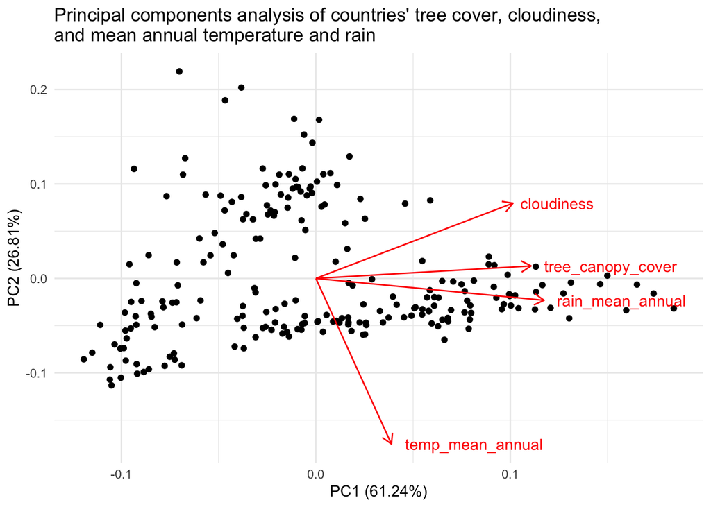

```r
# We begin by reading in the dataset and cleaning it up.
world_env_vars <- read.csv(here("data","world_env_vars.csv")) %>%
  clean_names() %>%
  mutate(across(where(is.character), tolower))

# Next, we are selecting the variables that we want to use in our PCA and creating a subset only containing those variables.
env_pca <- world_env_vars %>%
  select(rain_mean_annual, temp_mean_annual, cloudiness, tree_canopy_cover) %>%
  drop_na() %>%
  scale() %>%
  prcomp()

# Next, we create another subset of the data that drops the NAs for the variables we are interested in, but still included all other variables that we may want to use when we create a plot.
env_complete <- world_env_vars %>%
  drop_na(rain_mean_annual, temp_mean_annual, cloudiness, tree_canopy_cover)

# Finally, using the data subsets we created, we create a biplot for our PCA.
autoplot(env_pca,
         data = env_complete,
         loadings = TRUE,
         loadings.label = TRUE,
         loadings.label.hjust = -0.1
         ) +
  labs(title = "Principal components analysis of countries' tree cover, cloudiness,\nand mean annual temperature and rain") +
  theme_minimal()
```

**Figure 1.** A PCA biplot depicting cloudiness, tree canopy cover, mean annual temperature, and mean annual rain across countries. Arrows (red) indicate the loading of variables for the first two principal components, with the length of the arrow indicating variance, and the angle between arrows indicating correlation. Points (black) indicate the score of each case, based on the first two principal components, with closeness of points indicating similarity in the multivariate space.

## Summary

The principal components analysis of the country-level environmental and climactic data revealed the following findings:

- Cloudiness and tree canopy cover are moderately positively correlated
- Cloudiness and mean annual rain are moderately positively correlated
- Cloudiness and mean annual temperature are not correlated
- Tree canopy cover and mean annual rain are highly positively correlated
- Tree canopy cover and mean annual temperature are not correlated
- Mean annual rain and mean annual temperature are not correlated

Further analysis may be to look at how the correlation of these variables differs based on country.